# R Project Extra Questions

These are the extra problems in the R project about Adult Dataset

# setting the dataset up

|  | age | workclass | fnlwgt | education | education-num | marital-status | occupation | relationship | race | sex | capital-gain | capital-loss | hours-per-week | native-country | salary |
| --- | --- | --- | --- | --- | --- | --- | --- | --- | --- | --- | --- | --- | --- | --- | --- |
| 1 | 50 | Self-emp-not-inc | 83311 | Bachelors | 13 | Married-civ-spouse | Exec-managerial | Husband | White | Male | 0 | 0 | 13 | United-States | <=50K |
| 2 | 38 | Private | 215646 | HS-grad | 9 | Divorced | Handlers-cleaners | Not-in-family | White | Male | 0 | 0 | 40 | United-States | <=50K |
| 3 | 53 | Private | 234721 | 11th | 7 | Married-civ-spouse | Handlers-cleaners | Husband | Black | Male | 0 | 0 | 40 | United-States | <=50K |
| 4 | 28 | Private | 338409 | Bachelors | 13 | Married-civ-spouse | Prof-specialty | Wife | Black | Female | 0 | 0 | 40 | Cuba | <=50K |
| 5 | 37 | Private | 284582 | Masters | 14 | Married-civ-spouse | Exec-managerial | Wife | White | Female | 0 | 0 | 40 | United-States | <=50K |
| 6 | 49 | Private | 160187 | 9th | 5 | Married-spouse-absent | Other-service | Not-in-family | Black | Female | 0 | 0 | 16 | Jamaica | <=50K |

# Questions from document

## 1. How many men and women (sex feature) are represented in this dataset?

we can answer this using a bar chart, we can also use count. Thus, we have 21789 Males and 10771.

### table 1

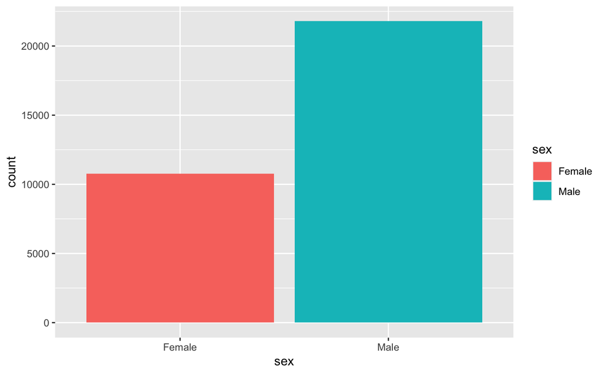

### table 2

| sex | n |
| --- | --- |
| Female | 10771 |
| Male | 21789 |

Observation: this gives us a ratio of almost 2 males to 1 females.  
If we ask why we have more males to females, it may be because males are more willing to take the survey and give out personal information. On the other hand, females are more wary and less likely to give out personal information.

## 2. What is the average age (age feature) of women and men?

In order to find the average age of women and men, we have to use summarise function in the dplyr library

| sex | average_age |
| --- | --- |
| Female | 36.85823 |
| Male | 39.43357 |

Thus, the average age of women is 36.85 and the average age of men is 39.43.  
Observation: the average ages between the sexes are pretty close.

## 3. What is the percentage of German/Chinese/Japanese/U.S. citizens (native-country feature)?

### table 1

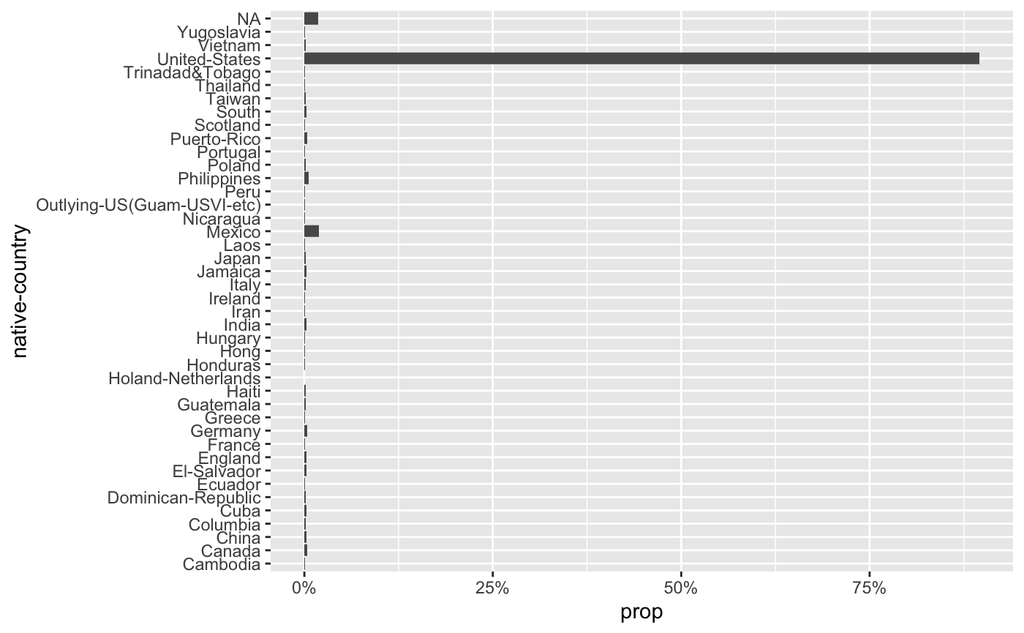

### table 2

| native-country | n | percentage |
| --- | --- | --- |
| United-States | 29169 | 89.585380835 |
| Mexico | 643 | 1.974815725 |
| NA | 583 | 1.790540541 |
| Philippines | 198 | 0.608108108 |
| Germany | 137 | 0.420761671 |
| Canada | 121 | 0.371621622 |
| Puerto-Rico | 114 | 0.350122850 |
| El-Salvador | 106 | 0.325552826 |
| India | 100 | 0.307125307 |
| Cuba | 95 | 0.291769042 |

[output cut: 32 more lines]

## 4. What are the mean and standard deviation of age for those who earn more than 50K per year (salary feature) and those who earn less than 50K per year?

In order to get the mean and standard deviation for this we must use summarise and group_by. Thus, for those who have salary <= 50K, the mean of age is 36.78365, and standard deviation of age is 14.02037. For those who have salary > 50K, the mean of age is 44.24984, and standard deviation of age is 10.51903

| salary | age_mean | age_sd |
| --- | --- | --- |
| <=50K | 36.78365 | 14.02037 |
| >50K | 44.24984 | 10.51903 |

Observation: the lower earners tend to be younger people and the higher earner tend to be older people.

## 5. Is it true that people who earn more than 50K have at least high school education? (education – Bachelors, Prof-school, Assoc-acdm, Assoc-voc, Masters or Doctorate feature)

The direct answer is no, there are people who earn more than 50K and have lower education than high school. However, by looking at the second graph, there are more people with high education and 50K than having low education and 50K Thus, people would be more likely to earn more than 50K if they are a HS-grad and above.

### table 1

[output not shown]

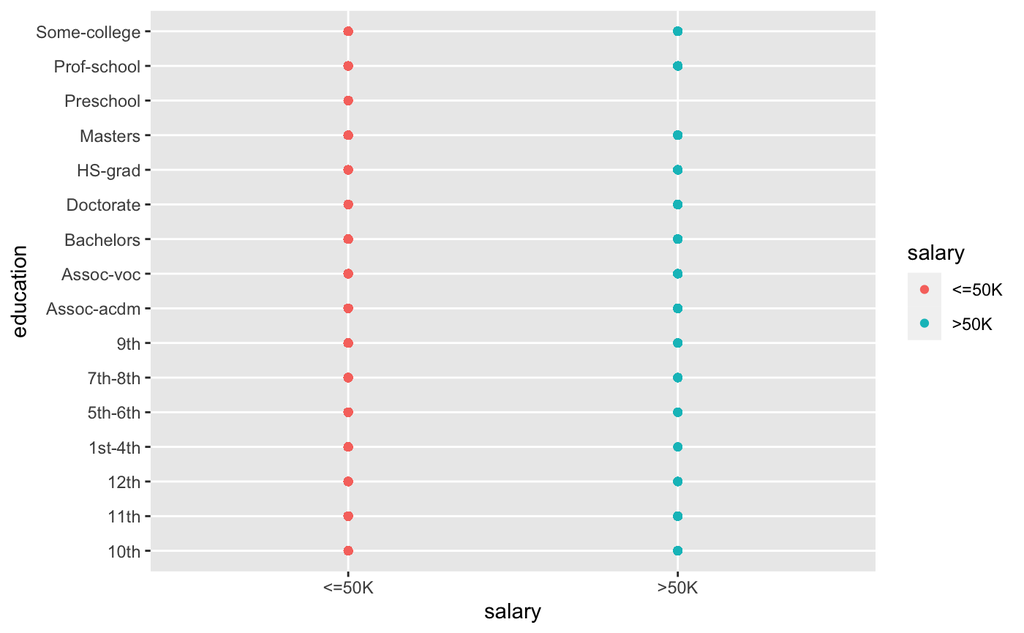

### table 2

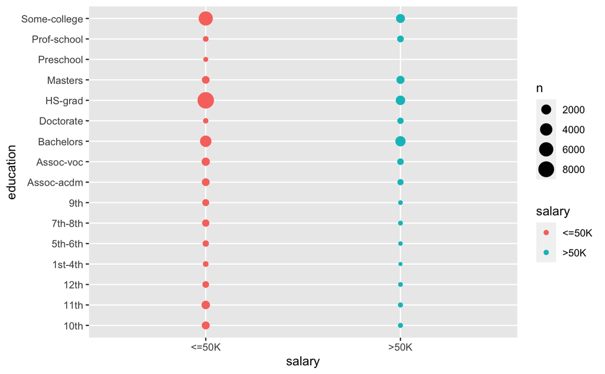

# My Questions

## 2. My question: Which job has the highest divorce and lowest divorce

people who work as Adm-clerical has the highest proportion of divorce with their spouse

people who work as Armed-Forces has the lowest to none proportion of divorce with their spouse

## 4. My question: Which job has the highest porportion of good pay

```
                           <=50K         >50K
  ?                 0.000000e+00 0.000000e+00
  Adm-clerical      1.061953e-01 1.650552e-02
  Armed-Forces      2.604421e-04 3.255526e-05
  Craft-repair      1.032002e-01 3.024384e-02
  Exec-managerial   6.830094e-02 6.406876e-02
  Farming-fishing   2.861608e-02 3.743855e-03
  Handlers-cleaners 4.180096e-02 2.799753e-03
  Machine-op-inspct 5.703682e-02 8.138816e-03
  Other-service     1.028095e-01 4.460071e-03
  Priv-house-serv   4.818179e-03 3.255526e-05
  Prof-specialty    7.425855e-02 6.052023e-02
  Protective-serv   1.425921e-02 6.869160e-03
  Sales             8.682489e-02 3.200182e-02
  Tech-support      2.099814e-02 9.213139e-03
  Transport-moving  4.157307e-02 1.041768e-02
```

| occupation | salary | n |
| --- | --- | --- |
| Adm-clerical | <=50K | 3262 |
| Adm-clerical | >50K | 507 |
| Armed-Forces | <=50K | 8 |
| Armed-Forces | >50K | 1 |
| Craft-repair | <=50K | 3170 |
| Craft-repair | >50K | 929 |
| Exec-managerial | <=50K | 2098 |
| Exec-managerial | >50K | 1968 |
| Farming-fishing | <=50K | 879 |
| Farming-fishing | >50K | 115 |

[output cut: 20 more lines]

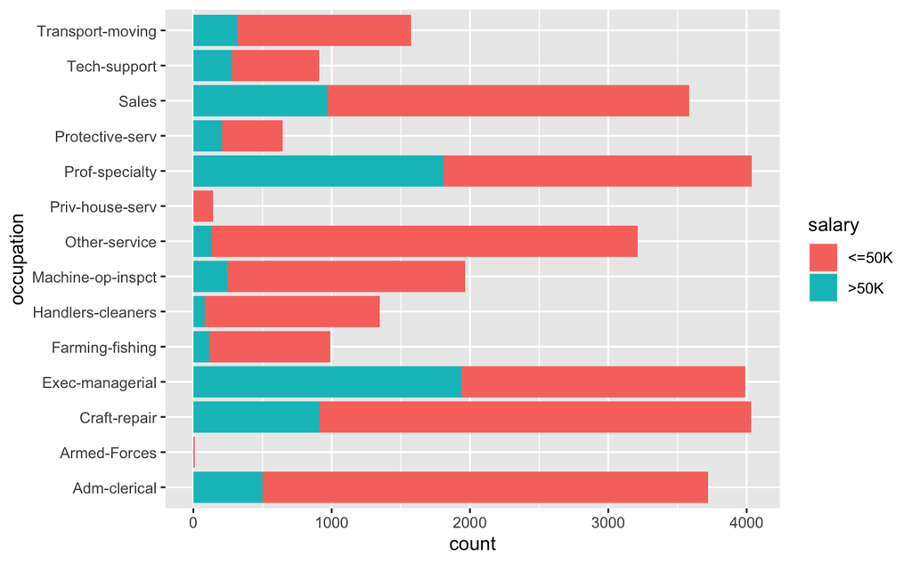

The jobs has the highest proportion of >50K pay is Prof-specialty and Exec-managerial  
These jobs have a higher chance than other jobs to receive a pay of >50K

## 5. My question: Which job have tend to have the most unmarried people

```
                        Divorced Married-AF-spouse Married-civ-spouse Married-spouse-absent Never-married    Separated      Widowed
  ?                 0.000000e+00      0.000000e+00       0.000000e+00          0.000000e+00  0.000000e+00 0.000000e+00 0.000000e+00
  Adm-clerical      2.666276e-02      1.627763e-04       3.209949e-02          1.920760e-03  5.176287e-02 4.785624e-03 5.306508e-03
  Armed-Forces      0.000000e+00      0.000000e+00       9.766579e-05          0.000000e+00  1.953316e-04 0.000000e+00 0.000000e+00
  Craft-repair      1.510564e-02      9.766579e-05       8.347169e-02          1.692874e-03  2.838819e-02 3.353192e-03 1.334766e-03
  Exec-managerial   1.966338e-02      3.255526e-05       7.956506e-02          1.009213e-03  2.601165e-02 3.060195e-03 3.027639e-03
  Farming-fishing   2.083537e-03      3.255526e-05       1.871928e-02          7.813263e-04  9.408471e-03 5.859947e-04 7.487710e-04
  Handlers-cleaners 4.167074e-03      0.000000e+00       1.520331e-02          7.487710e-04  2.265846e-02 1.237100e-03 5.859947e-04
  Machine-op-inspct 9.017808e-03      0.000000e+00       3.226227e-02          8.464368e-04  1.858905e-02 2.734642e-03 1.725429e-03
  Other-service     1.631019e-02      1.302211e-04       2.353745e-02          1.920760e-03  5.342319e-02 6.185500e-03 5.762281e-03
  Priv-house-serv   9.115474e-04      0.000000e+00       5.208842e-04          1.302211e-04  2.181203e-03 3.906632e-04 7.162158e-04
  Prof-specialty    1.754729e-02      9.766579e-05       6.921249e-02          1.530097e-03  4.017319e-02 3.222971e-03 2.995084e-03
  Protective-serv   2.571866e-03      3.255526e-05       1.246867e-02          1.627763e-04  5.078621e-03 5.208842e-04 2.929974e-04
  Sales             1.412898e-02      6.511053e-05       5.413940e-02          1.106879e-03  4.294039e-02 3.027639e-03 3.418303e-03
  Tech-support      4.557737e-03      0.000000e+00       1.315233e-02          1.953316e-04  1.077579e-02 9.115474e-04 6.185500e-04
  Transport-moving  5.892503e-03      3.255526e-05       3.235993e-02          6.185500e-04  1.106879e-02 1.204545e-03 8.138816e-04
```

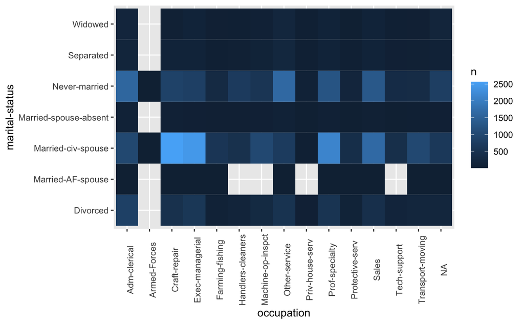

It seems that other service has the highest amount of unmarried people. Other service could be a waiter, bartender, dishwasher, or food deliverer. These service has a lower standards and isn’t back breaking, thus attracting unmarried people, who tend to be young.

## 6. My question: Which sex has more years of educaton and pay

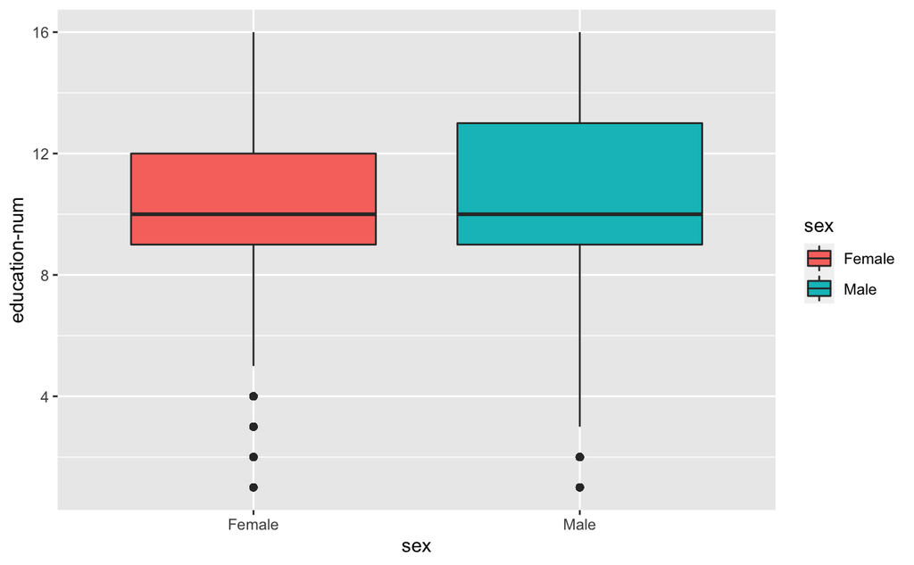

| sex | mean_education |
| --- | --- |
| Female | 10.03574 |
| Male | 10.10276 |

```
              <=50K       >50K
  Female 0.29459459 0.03621007
  Male   0.46458845 0.20460688
```

The median of the two sex have the same years of education, however, there are more males who tend to have more years of education than females, the males also have a slightly more years of education when we look at the mean. Also, males tend to have a higher ratio of >50K of 1/2, females have lower ratio of 3/29

## 7 My question: What is the relationship between marriage status and education num. Is it true that people with more education will less likely be in a relationship, because they are picky and driven in the work force.

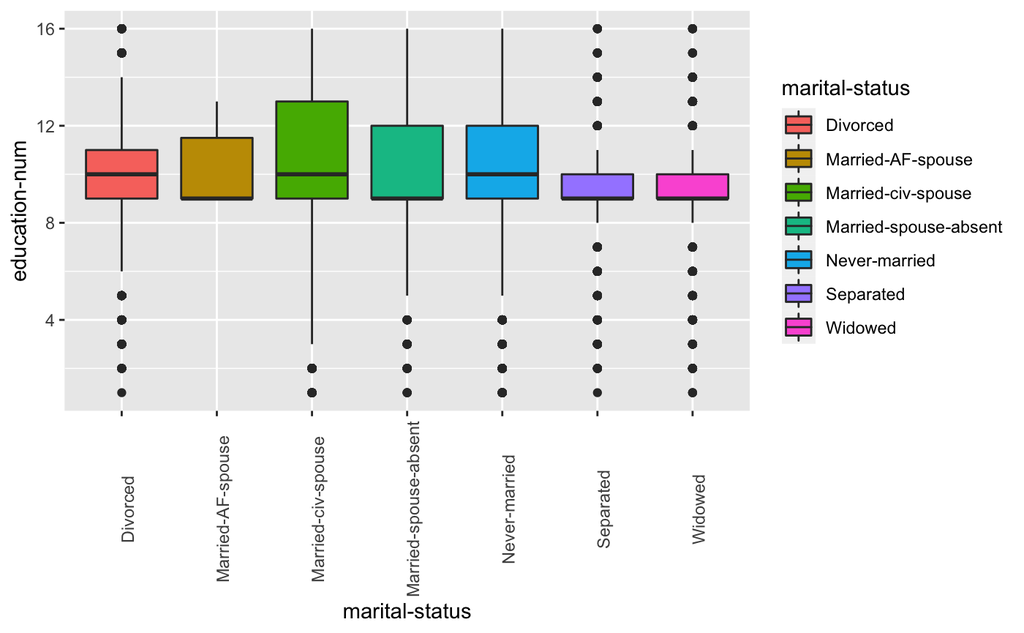

| marital-status | mean_education |
| --- | --- |
| Married-civ-spouse | 10.320646 |
| Married-AF-spouse | 10.173913 |
| Divorced | 10.030385 |
| Never-married | 9.962179 |
| Married-spouse-absent | 9.308612 |
| Separated | 9.293659 |
| Widowed | 9.093656 |

False, people who are married and is together with their spouse tends to have a more years in education, or people who have more years in education tend to be married and is together with their spouse. I believe it is that people with more education tends to be married and is together with their spouse. This may be because of finacial reasons because people who have more education tends to get a higer salary.

## 8 My question: Which kind of people tend to be widows, is it possible that there are aspects of the person that have a higher correlation with being a widow?

### lets look at the data of widows, what kind of people were they?

| age | workclass | fnlwgt | education | education-num | marital-status | occupation | relationship | race | sex | capital-gain | capital-loss | hours-per-week | native-country | salary |
| --- | --- | --- | --- | --- | --- | --- | --- | --- | --- | --- | --- | --- | --- | --- |
| 36 | Private | 108293 | HS-grad | 9 | Widowed | Other-service | Unmarried | White | Female | 0 | 0 | 24 | United-States | <=50K |
| 46 | State-gov | 102628 | Masters | 14 | Widowed | Protective-serv | Unmarried | White | Male | 0 | 0 | 40 | United-States | <=50K |
| 66 | Local-gov | 54826 | Assoc-voc | 11 | Widowed | Prof-specialty | Not-in-family | White | Female | 0 | 0 | 20 | United-States | <=50K |
| 75 | Private | 314209 | Assoc-voc | 11 | Widowed | Adm-clerical | Not-in-family | White | Female | 0 | 0 | 20 | Columbia | <=50K |
| 59 | Local-gov | 171328 | 10th | 6 | Widowed | Other-service | Unmarried | Black | Female | 0 | 0 | 30 | United-States | <=50K |
| 45 | Private | 187666 | Assoc-voc | 11 | Widowed | Exec-managerial | Not-in-family | White | Female | 0 | 0 | 45 | United-States | <=50K |
| 62 | Private | 159841 | HS-grad | 9 | Widowed | Other-service | Not-in-family | White | Female | 0 | 0 | 24 | United-States | <=50K |
| 65 | Private | 161400 | 11th | 7 | Widowed | Other-service | Unmarried | Other | Male | 0 | 0 | 40 | United-States | <=50K |
| 80 | NA | 107762 | HS-grad | 9 | Widowed | NA | Not-in-family | White | Male | 0 | 0 | 24 | United-States | <=50K |
| 44 | Private | 290521 | HS-grad | 9 | Widowed | Exec-managerial | Unmarried | Black | Female | 0 | 0 | 40 | United-States | <=50K |

[output cut: 983 more lines]

### average age of widow, and a boxplot

| mean_age |
| --- |
| 38.58163 |

| widow_mean_age |
| --- |
| 58.97583 |

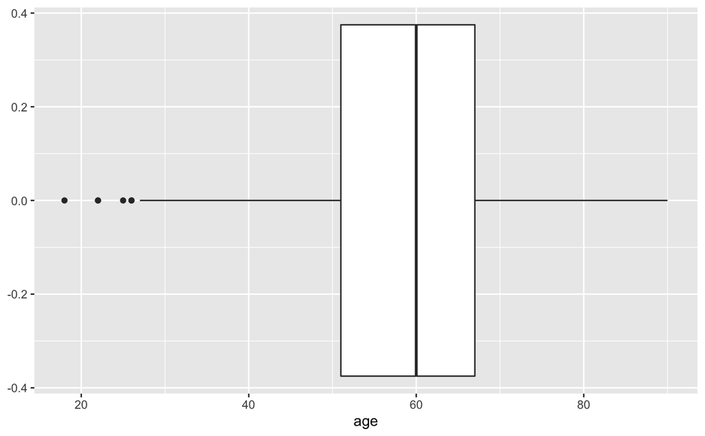

the age age of a widow is 58 years old, that is pretty old compared to our overall data which is 38 years old, also seeing that there are out-liers in the boxplot of people who are younger, we can tell that the overall age of widows are old and around 60.

### sex and education of widows

| sex | n |
| --- | --- |
| Female | 825 |
| Male | 168 |

| education | n |
| --- | --- |
| 10th | 39 |
| 11th | 38 |
| 12th | 10 |
| 1st-4th | 17 |
| 5th-6th | 14 |
| 7th-8th | 64 |
| 9th | 23 |
| Assoc-acdm | 23 |
| Assoc-voc | 41 |
| Bachelors | 82 |

[output cut: 6 more lines]

most of the widows in the data set are females, which is unsurprising because females often outlive their spouse. They also had low education, majority of them where only highschool gradates, which is not surprising because they are very old and education wasn’t as easily accessible when these women where young.